# MLCourseProject

Varun

2022-12-10

## **Background**

Using devices such as *Jawbone Up*, *Nike FuelBand*, and *Fitbit* it is now possible to collect a large amount of data about personal activity relatively inexpensively. These type of devices are part of the quantified self movement – a group of enthusiasts who take measurements about themselves regularly to improve their health, to find patterns in their behavior, or because they are tech geeks. One thing that people regularly do is quantify how *much* of a particular activity they do, but they rarely quantify *how well they do it*. In this project, your goal will be to use data from accelerometers on the belt, forearm, arm, and dumbell of 6 participants. They were asked to perform barbell lifts correctly and incorrectly in 5 different ways. More information is available from the website here: http://groupware.les.inf.puc-rio.br/har (see the section on the Weight Lifting Exercise Dataset).

### Acknowledgement:

The data for this project come from this source: http://web.archive.org/web/20161224072740/http:/groupware.les.inf.puc-rio.br/har. [Ugulino, W.](http://web.archive.org/web/20161224072740/http:/groupware.les.inf.puc-rio.br/collaborator.jsf?p1=ugulino); [Cardador, D.](http://web.archive.org/web/20161224072740/http:/groupware.les.inf.puc-rio.br/collaborator.jsf?p1=debora); [Vega, K.](http://web.archive.org/web/20161224072740/http:/groupware.les.inf.puc-rio.br/collaborator.jsf?p1=katia); [Velloso, E.](http://web.archive.org/web/20161224072740/http:/groupware.les.inf.puc-rio.br/collaborator.jsf?p1=evelloso); Milidiu, R.; [Fuks, H.](http://web.archive.org/web/20161224072740/http:/groupware.les.inf.puc-rio.br/collaborator.jsf?p1=hugo) [**Wearable Computing: Accelerometers’ Data Classification of Body Postures and Movements**](http://web.archive.org/web/20161224072740/http:/groupware.les.inf.puc-rio.br/work.jsf?p1=10335). Proceedings of 21st Brazilian Symposium on Artificial Intelligence. Advances in Artificial Intelligence - SBIA 2012. In: Lecture Notes in Computer Science. , pp. 52-61. Curitiba, PR: Springer Berlin / Heidelberg, 2012. ISBN 978-3-642-34458-9. DOI: 10.1007/978-3-642-34459-6_6.  
Read more: [http:/groupware.les.inf.puc-rio.br/har#ixzz4TkLUPdxa](http://web.archive.org/groupware.les.inf.puc-rio.br/har#ixzz4TkLUPdxa)

```r
library(tidyverse)
library(caret)
library(e1071)
library(glmnet)
library(MLmetrics)
library(caretEnsemble)
library(kernlab)
library(SmartEDA)
library(rattle)
```

```r
if(!file.exists("data")){
    dir.create("data")
}
fileURL<-"https://d396qusza40orc.cloudfront.net/predmachlearn/pml-training.csv"
    download.file(fileURL,destfile = "./data/pml-training.csv",method = "curl")
fileURL2<-"https://d396qusza40orc.cloudfront.net/predmachlearn/pml-testing.csv"
download.file(fileURL2,destfile = "./data/pml-testing.csv",method = "curl")
datedoenloaded<-date()
traindata<-read.csv("./data/pml-training.csv")
testdata<-read.csv("./data/pml-testing.csv")
dim(traindata)
```

```
## [1] 19622   160
```

```r
dim(testdata)
```

```
## [1]  20 160
```

There 160 variables in the dataset. Test se has 20 observations while training set has 19622.

### Exploring the data.

```r
ExpData(data=traindata,type = 1)
```

```
##                                           Descriptions       Value
## 1                                   Sample size (nrow)       19622
## 2                              No. of variables (ncol)         160
## 3                    No. of numeric/interger variables         123
## 4                              No. of factor variables           0
## 5                                No. of text variables          37
## 6                             No. of logical variables           0
## 7                          No. of identifier variables           1
## 8                                No. of date variables           0
## 9             No. of zero variance variables (uniform)           0
## 10               %. of variables having complete cases  37.5% (60)
## 11   %. of variables having >0% and <50% missing cases      0% (0)
## 12 %. of variables having >=50% and <90% missing cases      0% (0)
## 13          %. of variables having >=90% missing cases 62.5% (100)
```

### Cleaning the data

```r
traindata2<-traindata[,colMeans(is.na(traindata))<0.9] # removing more than 90%NA
traindata2<-traindata2[,-c(1:7)]
```

Removing near zero variance varibles in the data.

```r
nearzerovar<-nearZeroVar(traindata2)
traindata2<-traindata2[,-nearzerovar]
dim(traindata2)
```

```
## [1] 19622    53
```

Now we split data into subtrain and validation set.

```r
inTrain<-createDataPartition(y=traindata2$classe,p=0.7,list=F)
subtrain<-traindata2[inTrain,]
valid<-traindata2[-inTrain,]
dim(subtrain)
```

```
## [1] 13737    53
```

```r
dim(valid)
```

```
## [1] 5885   53
```

### Creation of models

Here we will train the data using Random Forest,SVM, Decision tree,and Gradient Boosted tree Models. We also set up control for training to use 3-fold cross validation.

```r
control<-trainControl(method="cv", number=3,verboseIter = F)
```

### Random Forest Model

```r
modlrf<-train(classe~.,data=subtrain,method="rf",trControl=control,tuneLength=5)
pred_rf<-predict(modlrf,valid)
cmrf<-confusionMatrix(pred_rf,factor(valid$classe))
cmrf
```

```
## Confusion Matrix and Statistics
##
##           Reference
## Prediction    A    B    C    D    E
##          A 1674    7    0    0    0
##          B    0 1129    4    0    0
##          C    0    3 1017    6    3
##          D    0    0    5  957    2
##          E    0    0    0    1 1077
##
## Overall Statistics
##
##                Accuracy : 0.9947
##                  95% CI : (0.9925, 0.9964)
##     No Information Rate : 0.2845
##     P-Value [Acc > NIR] : < 2.2e-16
##
##                   Kappa : 0.9933
##
##  Mcnemar's Test P-Value : NA
##
## Statistics by Class:
##
##                      Class: A Class: B Class: C Class: D Class: E
## Sensitivity            1.0000   0.9912   0.9912   0.9927   0.9954
## Specificity            0.9983   0.9992   0.9975   0.9986   0.9998
## Pos Pred Value         0.9958   0.9965   0.9883   0.9927   0.9991
## Neg Pred Value         1.0000   0.9979   0.9981   0.9986   0.9990
## Prevalence             0.2845   0.1935   0.1743   0.1638   0.1839
## Detection Rate         0.2845   0.1918   0.1728   0.1626   0.1830
## Detection Prevalence   0.2856   0.1925   0.1749   0.1638   0.1832
## Balanced Accuracy      0.9992   0.9952   0.9944   0.9957   0.9976
```

### SVM Model

```r
modlsvm<-train(classe~.,method="svmLinear",data=subtrain,trControl=control,tuneLength=5,verbose=F)
pred_svm<-predict(modlsvm,valid)
cmsvm<-confusionMatrix(pred_svm,factor(valid$classe))
```

### Decision Tree

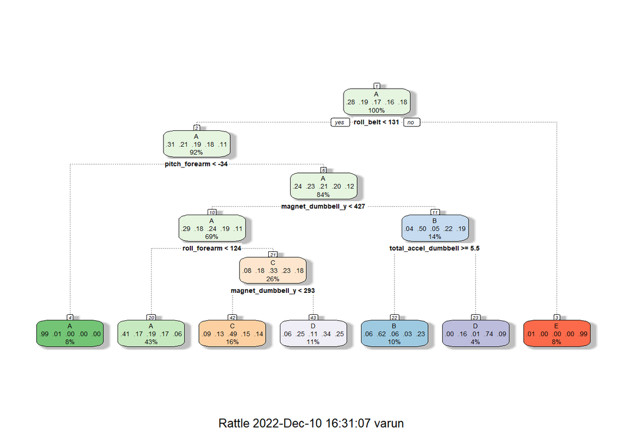

```r
modl_dtree<-train(classe~.,data=subtrain,method="rpart",trControl=control,tuneLength=5)
fancyRpartPlot(modl_dtree$finalModel)
```

```r
pre_dtree<-predict(modl_dtree,valid)
cmdtree<-confusionMatrix(pre_dtree,factor(valid$classe))
cmdtree
```

```
## Confusion Matrix and Statistics
##
##           Reference
## Prediction    A    B    C    D    E
##          A 1504  496  467  422  158
##          B   40  343   34   15  127
##          C   98  124  453  138  146
##          D   28  176   72  389  170
##          E    4    0    0    0  481
##
## Overall Statistics
##
##                Accuracy : 0.5387
##                  95% CI : (0.5258, 0.5515)
##     No Information Rate : 0.2845
##     P-Value [Acc > NIR] : < 2.2e-16
##
##                   Kappa : 0.3989
##
##  Mcnemar's Test P-Value : < 2.2e-16
##
## Statistics by Class:
##
##                      Class: A Class: B Class: C Class: D Class: E
## Sensitivity            0.8984  0.30114  0.44152   0.4035  0.44455
## Specificity            0.6336  0.95449  0.89586   0.9094  0.99917
## Pos Pred Value         0.4936  0.61360  0.47237   0.4659  0.99175
## Neg Pred Value         0.9401  0.85054  0.88368   0.8861  0.88870
## Prevalence             0.2845  0.19354  0.17434   0.1638  0.18386
## Detection Rate         0.2556  0.05828  0.07698   0.0661  0.08173
## Detection Prevalence   0.5178  0.09499  0.16296   0.1419  0.08241
## Balanced Accuracy      0.7660  0.62781  0.66869   0.6564  0.72186
```

### Gradient Boosted Trees

```r
mdlgbm<-train(classe~.,data=subtrain,method="gbm",trControl=control,tuneLength=5,verbose=F)
pre_gbm<-predict(mdlgbm,valid)
cmgbm<-confusionMatrix(pre_gbm,factor(valid$classe))
```

```r
SVMModel<-cmsvm$overall["Accuracy"]
GBMModel<-cmgbm$overall["Accuracy"]
RandomForestModel<-cmrf$overall["Accuracy"]
DecisionTreeModel<-cmdtree$overall["Accuracy"]
ans<-cbind(SVMModel,GBMModel,RandomForestModel,DecisionTreeModel)
ans
```

```
##           SVMModel  GBMModel RandomForestModel DecisionTreeModel
## Accuracy 0.7826678 0.9896347         0.9947324         0.5386576
```

From above analysis it is seen that Random Forest Model is the best among others. So we use the same to predict the test data.

```r
finalpred<-predict(modlrf,testdata)
finalpred
```

```
##  [1] B A B A A E D B A A B C B A E E A B B B
## Levels: A B C D E
```